# Data Analysis 2

# Finding #1

Boxplot of age by job, sorted by median age  
**Insight:** *There exist outliers of retirees in their 20s, which may represent erroneous sample.*

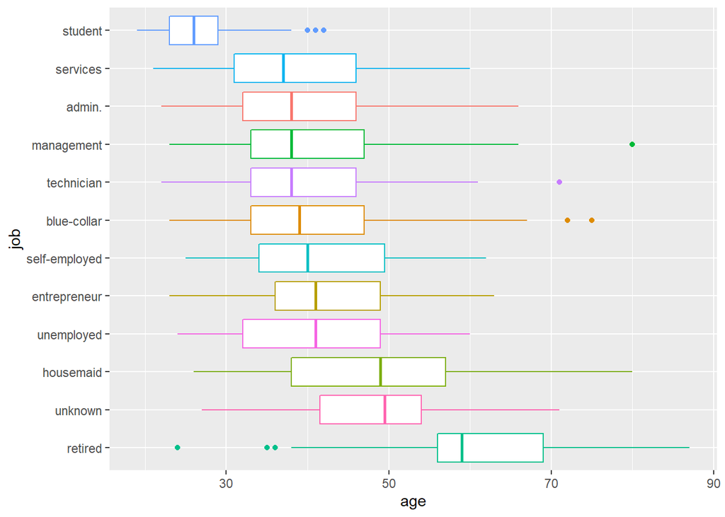

```r
ggplot(bank, aes(job, age, color=job)) + geom_boxplot()+coord_flip()+
  theme(legend.position="NA")+
scale_x_discrete(limit = rev(levels(reorder(bank$job, bank$age, FUN = median))))
```

# Finding #2 Boxplot of age by education, split by marital status  
**Insight:** *In general, age of single people are younger than that of married or divorced.*

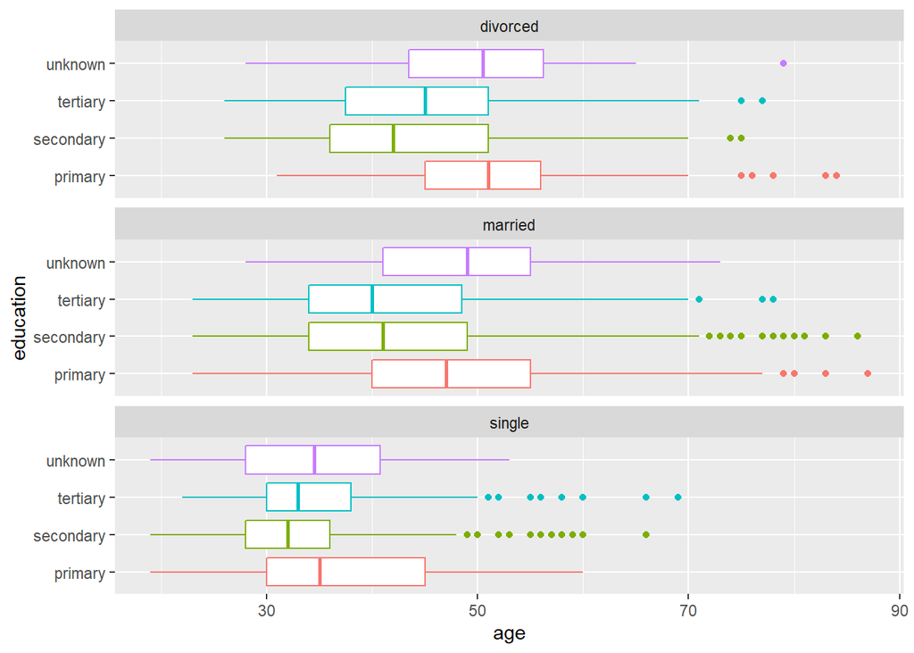

```r
ggplot(bank, aes(education, age, color=education)) +
  geom_boxplot()+
  coord_flip()+
  theme(legend.position="NA")+
  facet_wrap( ~ marital,nrow = 3)
```

#Finding #3 Plot of people with a personal loan and housing loan by age  
**Insight:** *There are much more people with housing loan as compared to personal loan across all ages*

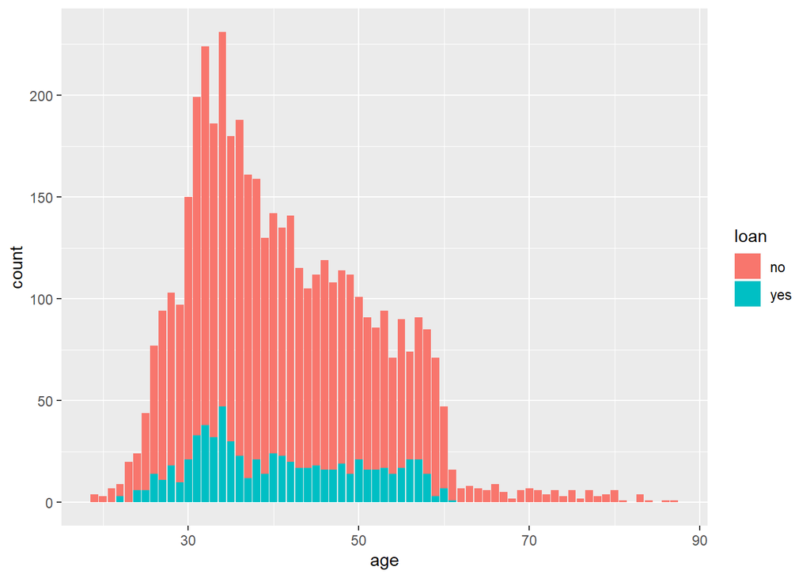

```r
  ggplot(bank, aes(age, fill = loan)) +
    geom_bar()
```